Author

Perpetua Senatus

# NYC Department of Homeless Services Daily Shelter Census Analysis

## Introduction

Homelessness remains one of the most pressing social and administrative challenges facing New York City, impacting thousands of individuals and families daily. My interest in this topic stems from my daily commute; as someone who takes the train to come to campus, I am frequently confronted with the human reality of this crisis. I often see people sleeping on the trains and encounter families with children asking for money in the stations or in the trains. These experiences have left me constantly questioning why these individuals are not provided a safe place to say for their well-being, are the shelters simply full, or are there other barriers to entry?. To better understand these questions, I chose to study the **NYC Department of Homeless Services(DHS) Daily Report** because it provides a transparent, high-frequency look at the scale of the city’s shelter system and the specific demographics it serves. This project aims to perform detective work through exploratory data analysis to uncover trends in shelter residency. Specially, I am interested in studying how the total population has fluctuated over the last few years, whether there are seasonal patterns in census counts, and which subgroups are most responsible for shifts in the overall population.

**Context:** DHS manages an extensive work of shelters across the five boroughs, and these daily census counts are vital for resource allocation and policy evaluation.

## Data

### Description

The data is provided by the **New York City Department of Homeless Services(DHS)** and represents an official daily census of families and individuals residing within the city’s shelter system. The dataset is **updated daily** on the NYC Open Data portal, ensuring the most current figures are available for public audit. As of the latest records used in this analysis, the dataset contains **13 columns** and approximately 1**887 rows,** with each rows representing one Date of Census. The key variablesinclude the **Total Individuals in Shelter** (sum of all adults and children in the system) **and Demographic Breakddowns** (Single Adult Men/Women and Families with Children).

**Technical Note on Data Cleaning:** A significant technical issue identified during initial inspection is that the **date_of_census** variable is currently stored as a character string(e.g ., 03/16/2021). To perform proper time series analysis and allow RStudio to correctly label axes by year, day, or month, we will convert this column to a Date class using functions like as.Date() or lubridate::mdy().

**Dataset Link:** [DHS Daily Report- NYC Open Data](https://data.cityofnewyork.us/Social-Services/DHS-Daily-Report/k46n-sa2m/about_data)

### Missing value analysis

```
[1] 1887
```

```
[1] "Date"
```

```
[1] "2021-03-01" "2026-04-30"
```

```
[1] "2021-03-01" "2021-03-02" "2021-03-03" "2021-03-04" "2021-03-05"
[6] "2021-03-06"
```

**This long list of 0 confirms that all 13 variables contain zero missing values:**

```
                                         date_of_census
                                                      0
                                total_adults_in_shelter
                                                      0
                              total_children_in_shelter
                                                      0
                           total_individuals_in_shelter
                                                      0
                            single_adult_men_in_shelter
                                                      0
                          single_adult_women_in_shelter
                                                      0
                         total_single_adults_in_shelter
                                                      0
                      families_with_children_in_shelter
                                                      0
            adults_in_families_with_children_in_shelter
                                                      0
          children_in_families_with_children_in_shelter
                                                      0
total_individuals_in_families_with_children_in_shelter_
                                                      0
                              adult_families_in_shelter
                                                      0
               individuals_in_adult_families_in_shelter
                                                      0
```

**Graph 1 :** This map confirms that our data is **100% complete** across all 13 variables. It shows that the DHS has a very reliable and consistent daily reporting process (high level of administrative integrity) . The lack of gaps suggests that the data is tidy and ready for analysis:

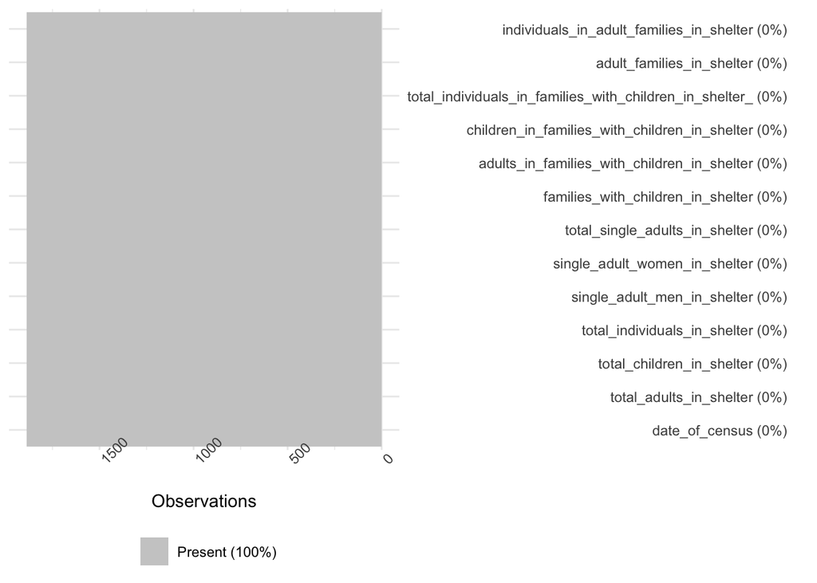

**Graph 2:** To further validate the completeness of the data, checking each variable one by one confirms that every key metric from total adult count down to specific family demographics, has **zero missing values.** This consistency is key to our detective work because it means we can trust that the totals are not being skewed by one group being under-reported or overlooked:

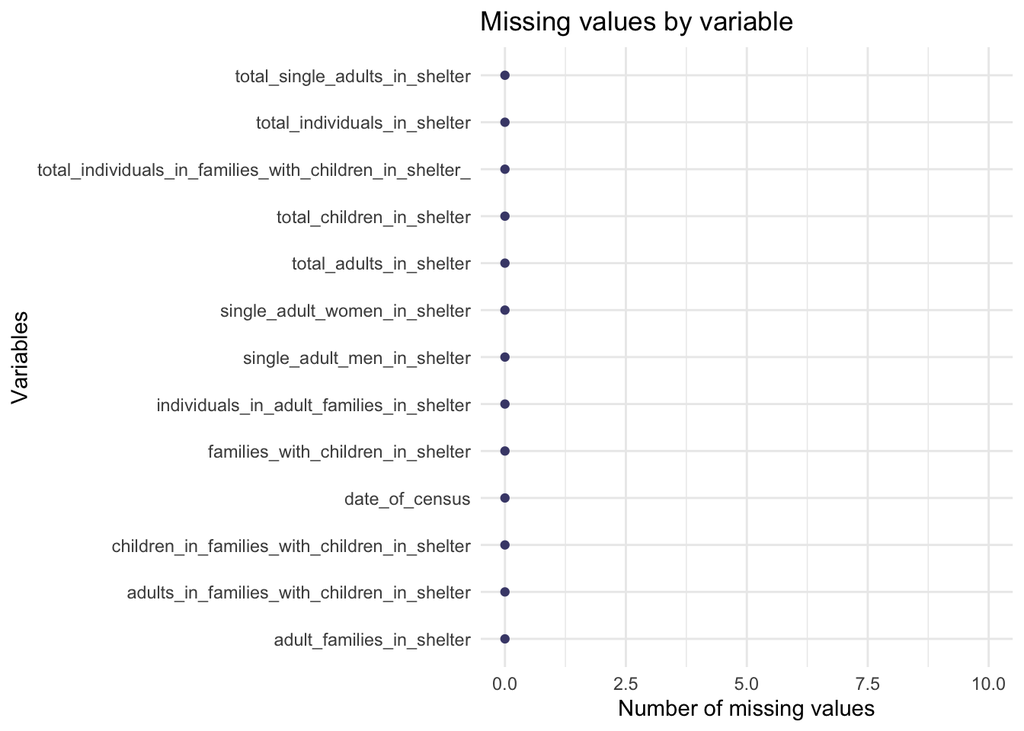

## Results

### **Initial visualizations to understand the story of the data**

### **1. Histogram of Total Individuals to see the distribution**

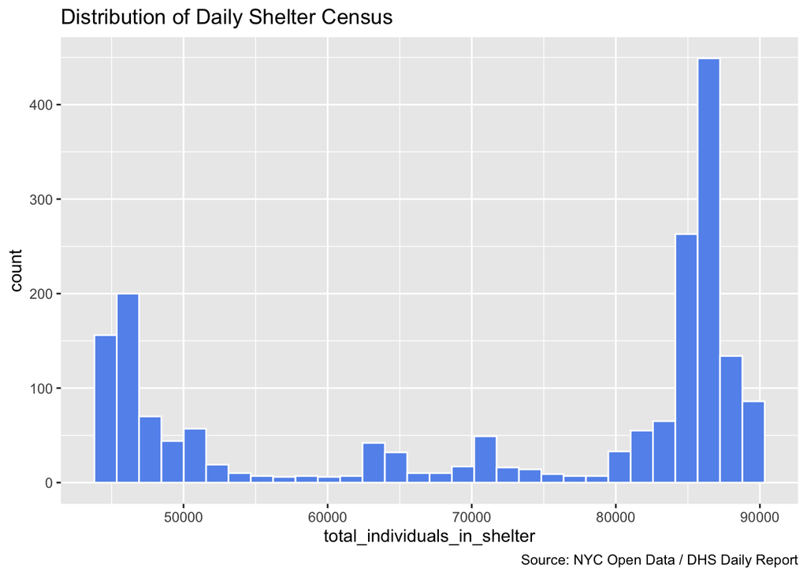

### 2. Time series plot to see trends over time

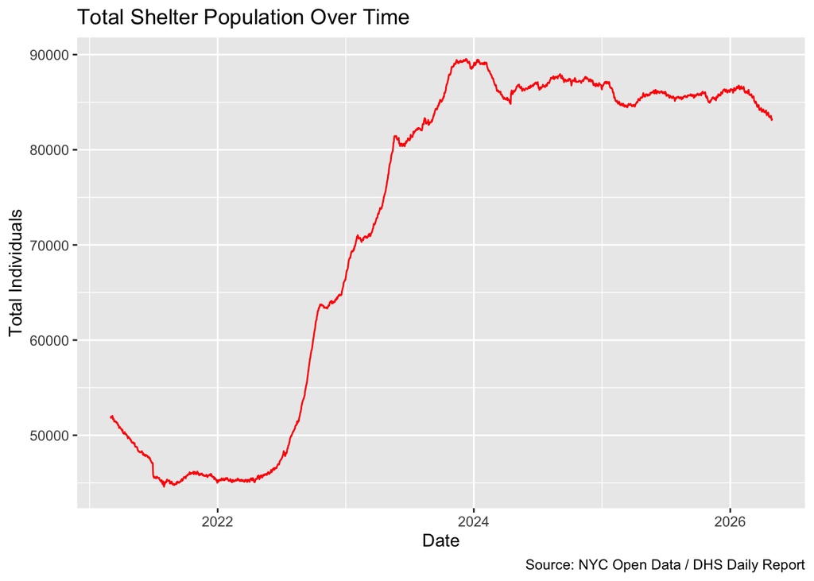

### Question 1: How has the total NYC shelter population evolved between 2021 and 2026? Does the growth trajectory suggest a system reaching its capacity

#### 1.1 The Impact of Economic Policy and Housing Costs

#### Finding whether the city can physically and financially sustain the rapid increase in census counts observed in recent years.

This tracks the effectiveness of **‘Right to Shelter’** laws and the impact of rising NYC rent prices. A steady increase suggests that housing affordability policies may not be keeping pace with demand:

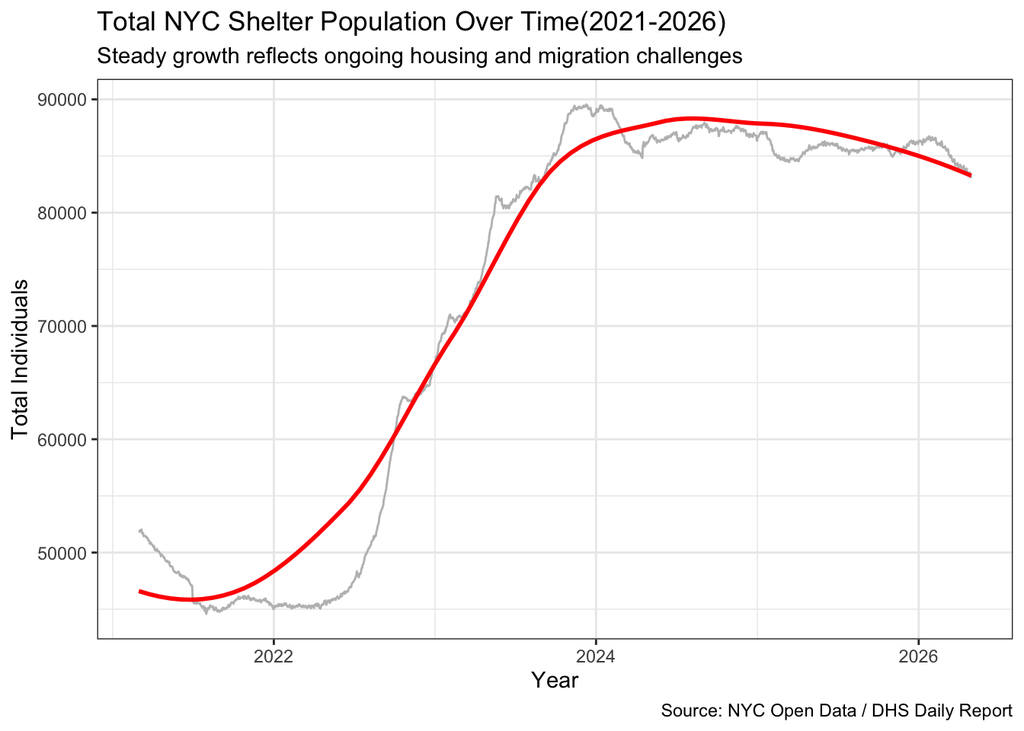

### Question 2: What is the ratio of single adults vs. families with children over time? **How has the composition of the shelter system shifted over time?**

**2.1 Demographic Shifts : Families vs. Single Adults / systemic growth and the breaking point**

This is a hot-button issue in NYC. A sudden spike in **single adults often** correlates with the recent migrant arrivals, whereas a spike in **families** might point toward a domestic eviction crisis.

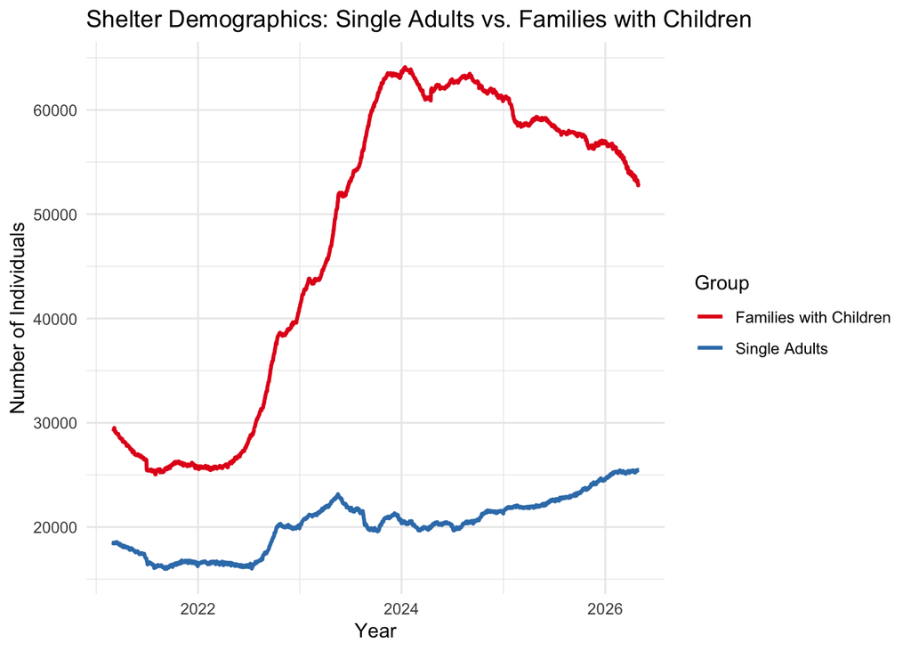

**2.2 Detailed Family Composition**

To find the specific breakdown of people in family shelters (Adults vs. Children).

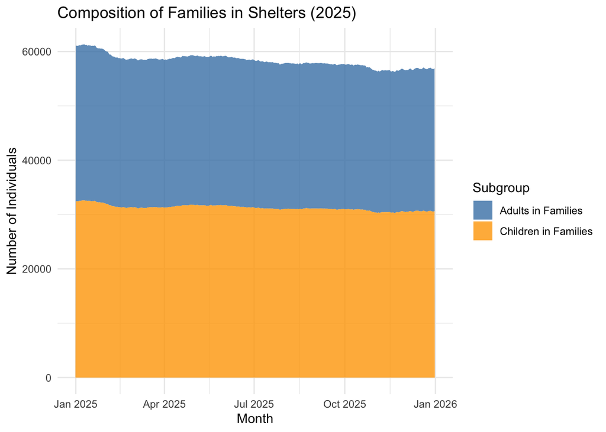

### Question 3: Does the shelter population peak during winter months? Doe the daily census counts reveal predictable seasonal patterns, specially during winter months?

### **3.1 Seasonal Trends and Public Health / Seasonality and the code blue effect**

To investigate if the people I see sleeping on trains are successfully transitioned into shelters during extreme cold, or if the winter spike in census data is becoming the new year round baseline.

This evaluates the city’s emergency winter response**(Code Blue).** If the population spikes significantly every january, it shows how weather-related public health policies drive DHS operations.

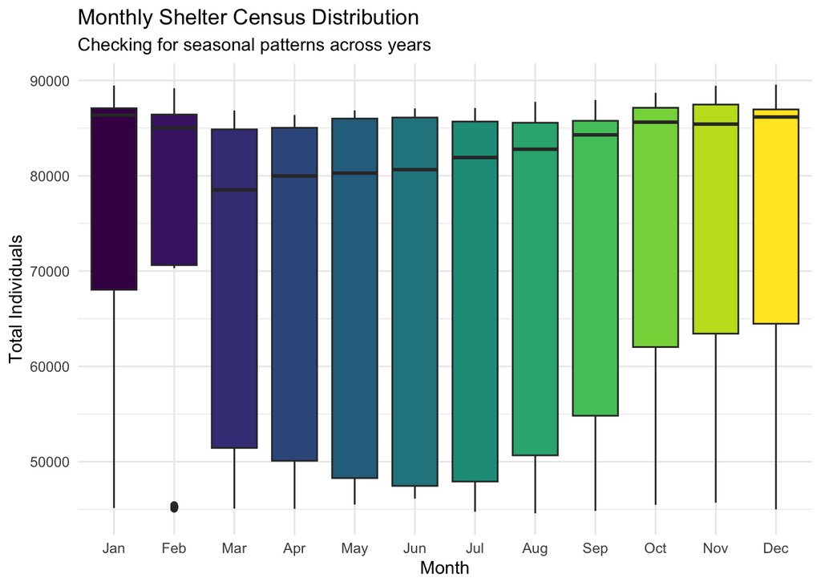